# Praca domowa 1

Witold Merkel

6 10 2019

# 1 Wprowadzenie

W tej pracy zajmiemy się porównywaniem czasu tworzenia się takich samych wykresów przy użyciu 3 różnych pakietów. Tymi pakietami są: *ggplot2*, *lattice* oraz *graphics*.

Kolejność wyświetlania danych jest następująca, najpierw napisane jest przy pomocy jakiego pakietu uzyskaliśmy wykres, potem przedstawiony jest wykres, a na koniec pokazany jest czas tworzenia.

# 2 Scatter plot

W celu porównania czasu w tym przypadku losowo wygenerujemy 250 punktów. Do generowania punktów użyjemy funkcji: *rnorm()*, czyli będą to punkty z rozkładu normalnego o wartości oczekiwanej równej 0 oraz wariancji równej 1.

```
## [1] "Graphics"
```

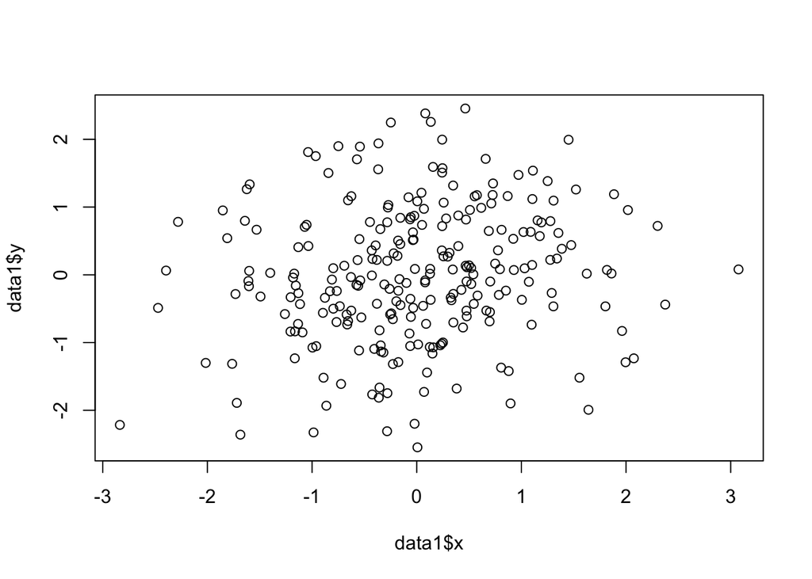

```
##    user  system elapsed
##   0.040   0.006   0.052
```

```
## [1] "GGplot"
```

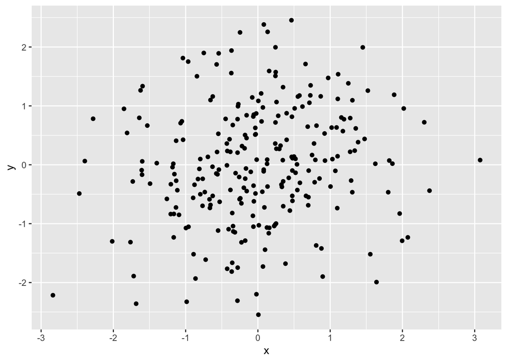

```
##    user  system elapsed
##   0.002   0.000   0.002
```

```
## [1] "Lattice"
```

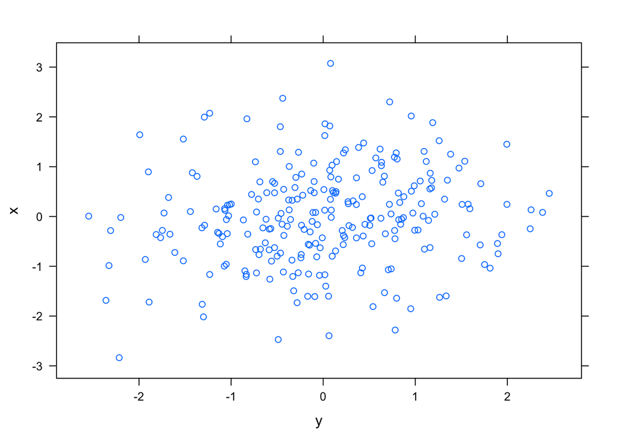

```
##    user  system elapsed
##   0.001   0.000   0.001
```

# 3 Histogram

W tej sekcji przybliżymy rozkład gamma z parametrami 8 i 24 przy użyciu histogramu i funckji *rgamma()*.

```
## [1] "Graphics"
```

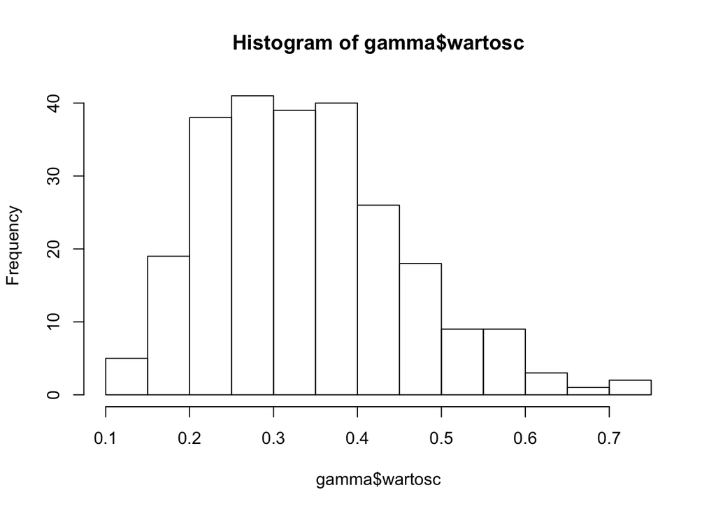

```
##    user  system elapsed
##   0.053   0.010   0.169
```

```
## [1] "Ggplot"
```

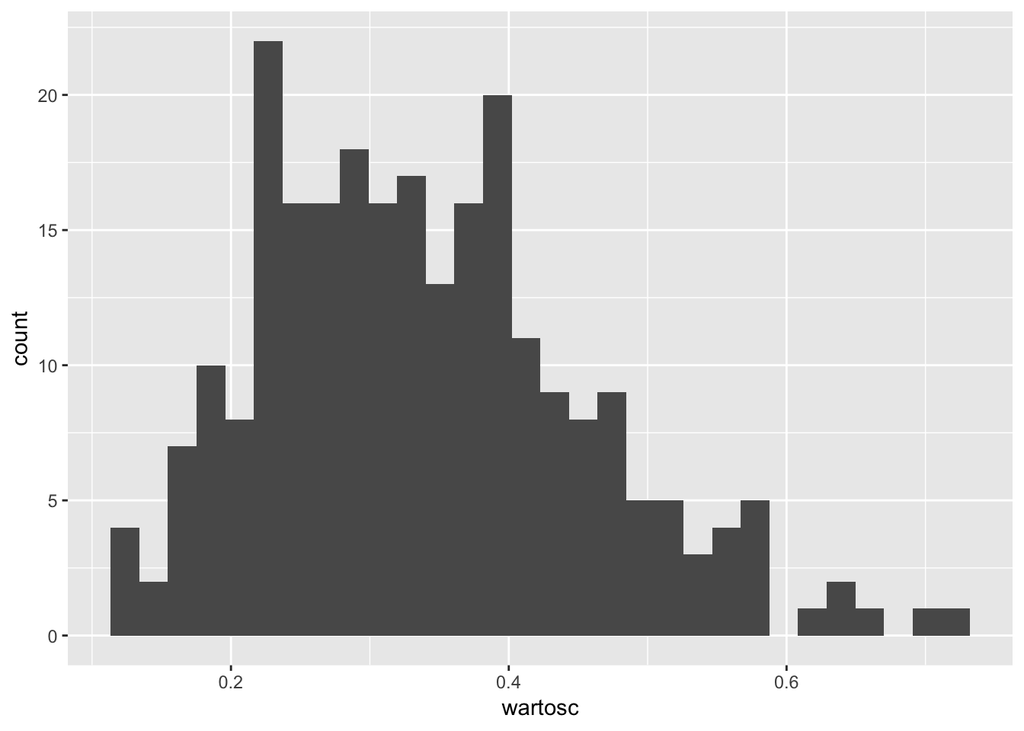

```
##    user  system elapsed
##   0.005   0.000   0.009
```

```
## [1] "Lattice"
```

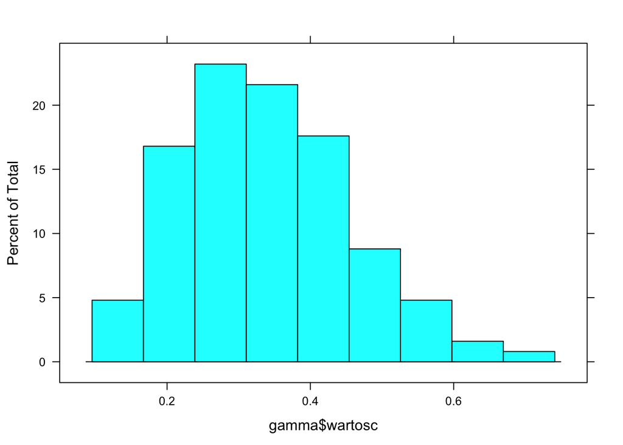

```
##    user  system elapsed
##   0.005   0.000   0.008
```

# 4 Bar plot

W tej sekcji spojrzymy na rozłożenie tego w jakich klasach byli pasażerowie rejsu tytanika.

```
## [1] "Graphics"
```

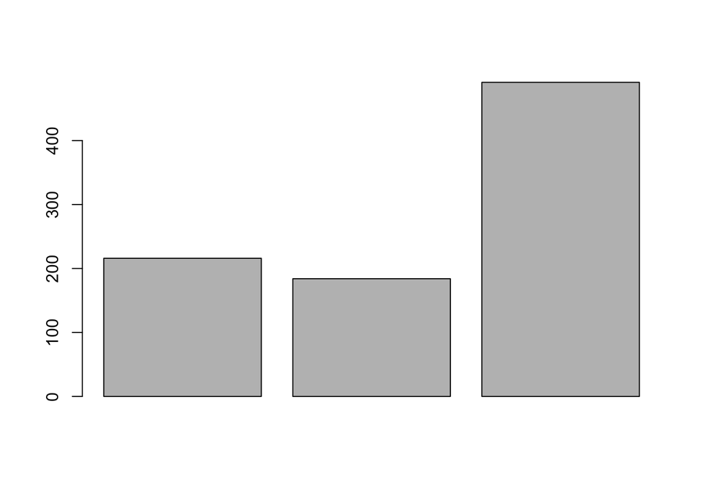

```
##    user  system elapsed
##   0.042   0.007   0.188
```

```
## [1] "Ggplot"
```

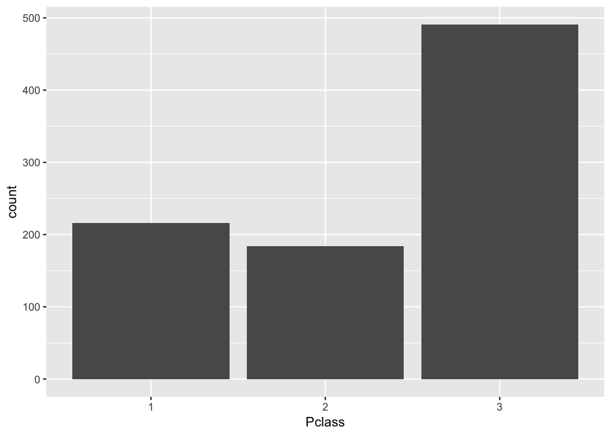

```
##    user  system elapsed
##   0.004   0.000   0.005
```

```
## [1] "Lattice"
```

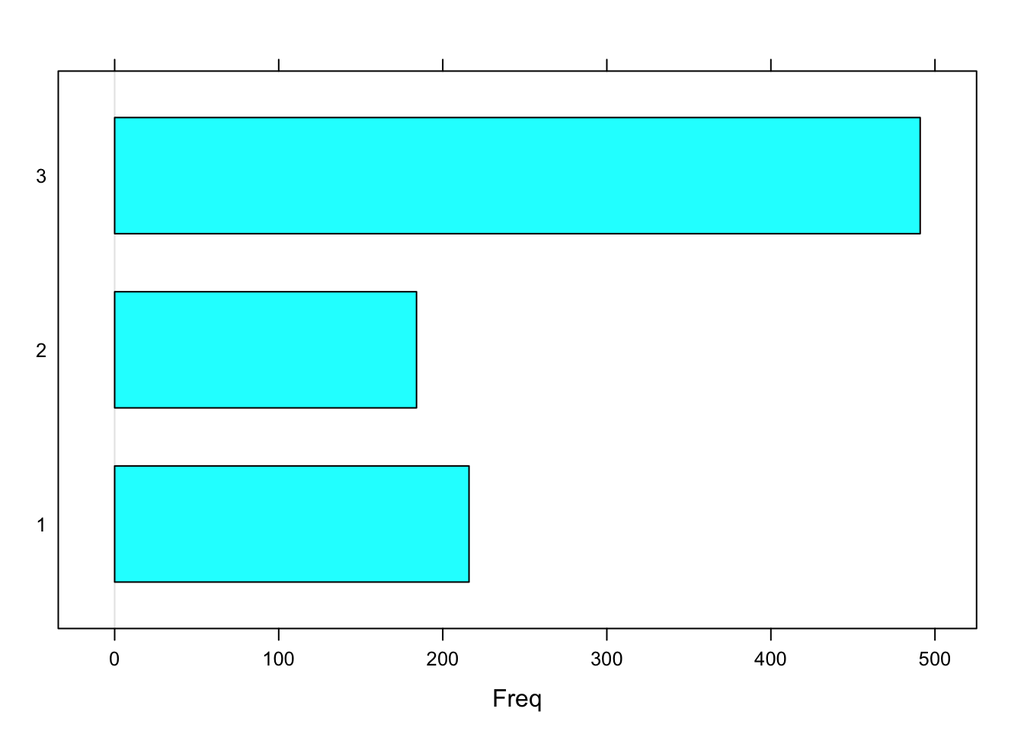

```
##    user  system elapsed
##   0.004   0.000   0.005
```

# 5 Line plot

Przedstawimy tu wykres liniowy cen zamknięć kursu DAX na giełdzie w latach 1991-1998.

```
## [1] "Graphics"
```

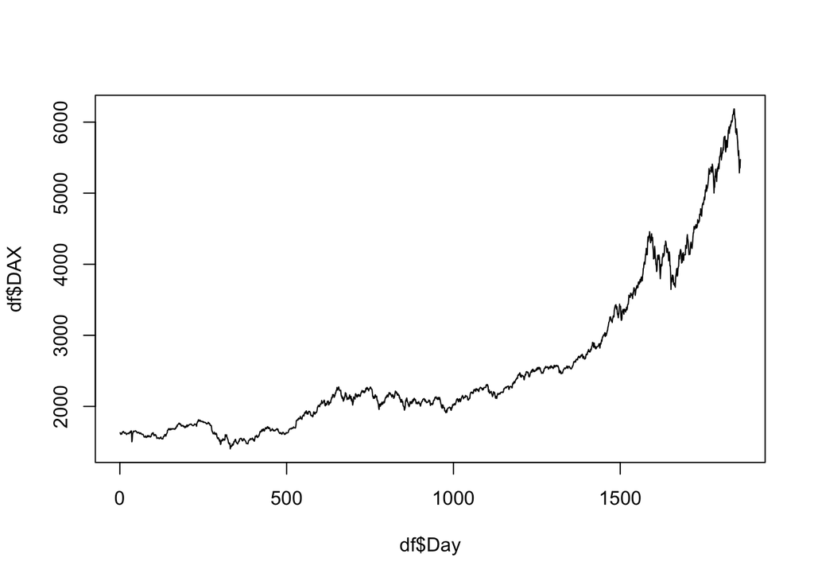

```
##    user  system elapsed
##   0.063   0.010   0.132
```

```
## [1] "Ggplot"
```

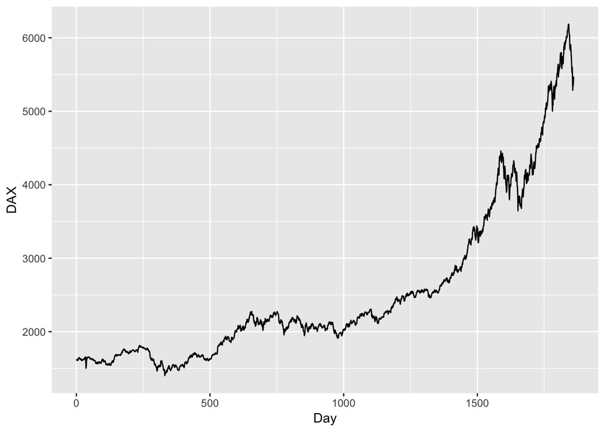

```
##    user  system elapsed
##   0.004   0.000   0.009
```

```
## [1] "Lattice"
```

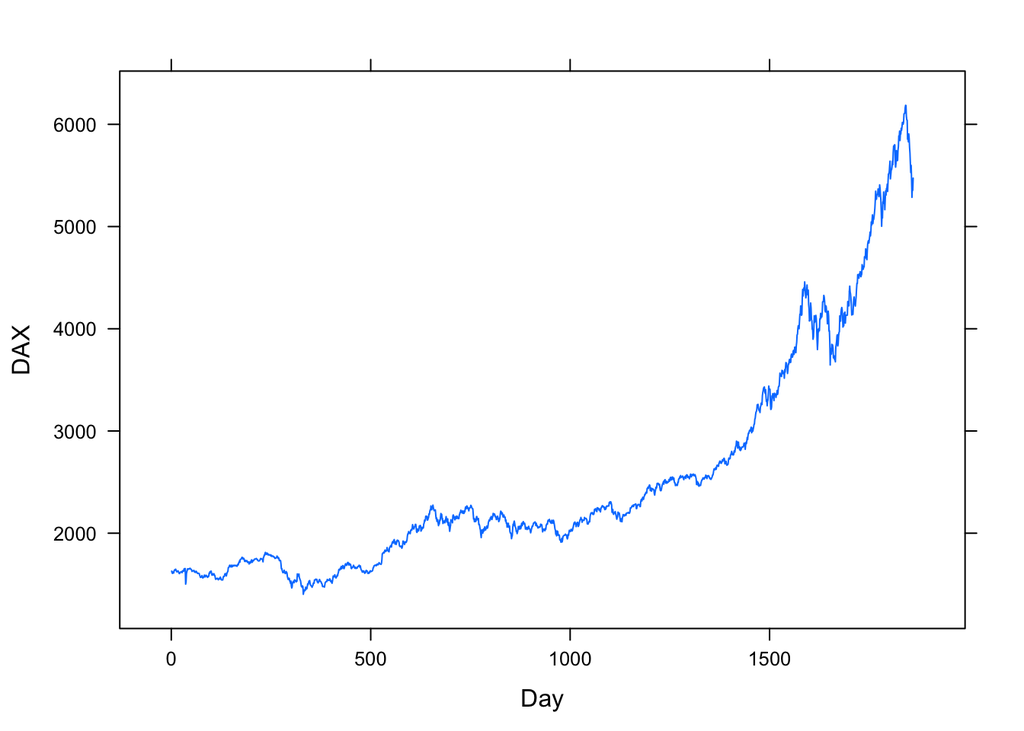

```
##    user  system elapsed
##   0.002   0.000   0.006
```

# 6 Boxplot

Tutaj posłużymy się zbiorem danych, który jest już każdemu znany, mianowicie *mtcars*.

```
## [1] "Graphics"
```

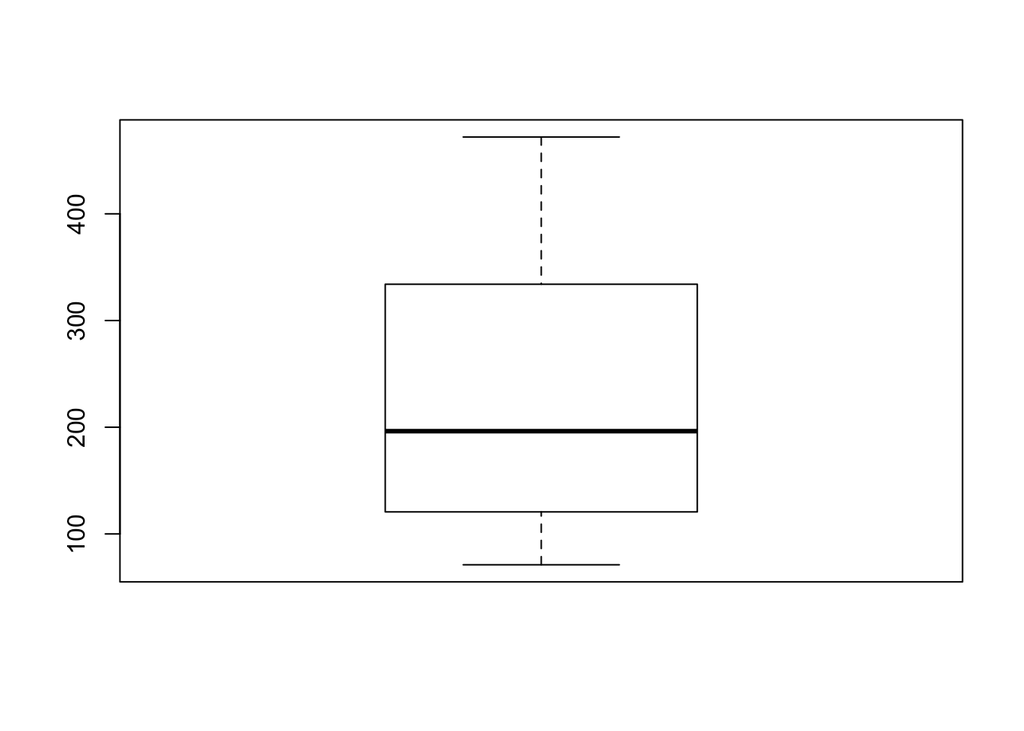

```
##    user  system elapsed
##   0.045   0.010   0.305
```

```
## [1] "Ggplot"
```

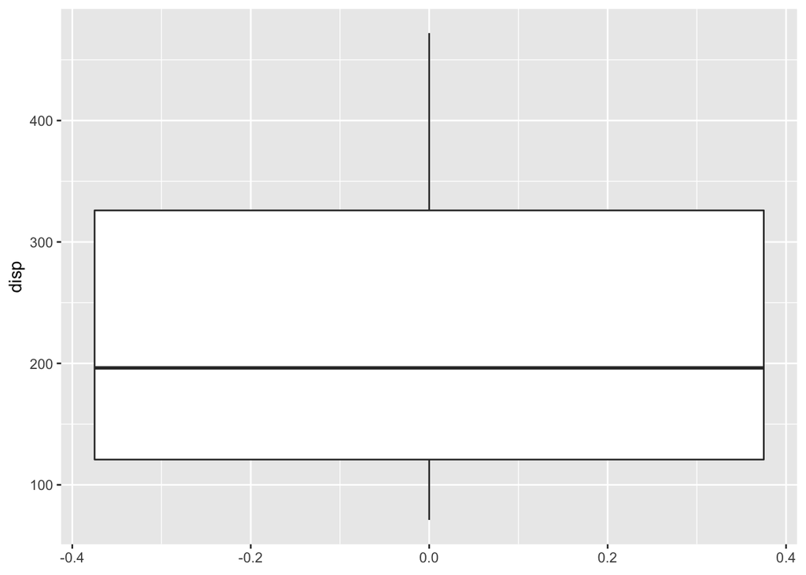

```
##    user  system elapsed
##   0.005   0.000   0.019
```

```
## [1] "Lattice"
```

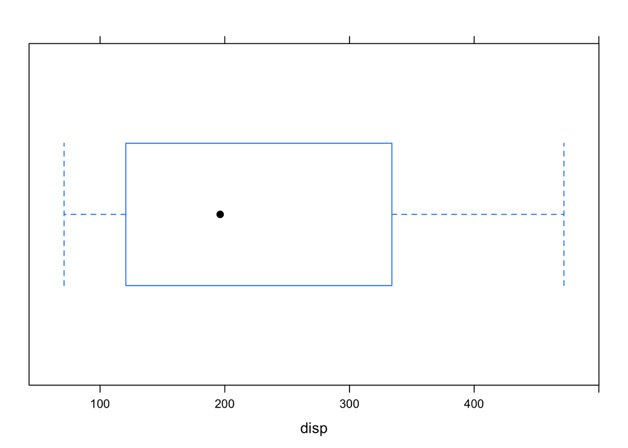

```
##    user  system elapsed
##   0.005   0.000   0.019
```

# 7 Podsumowanie

Widzimy, że w każdym z tych przypadków zdecydowanie najdłużej trwa tworzenie się wykresu przy użyciu pakietu: *graphics*, jest to zdecydowana różnica. Pozostałe dwa pakiety mają zbliżony czas działania, minimalnie lepszy prawie zawsze oprócz przypadku *Column plota* okazuje się pakiet *lattice*.

Dla ułatwienia czytelnikowi na koniec porównamy te czasy na wykresach.

## 7.1 Scatter plot

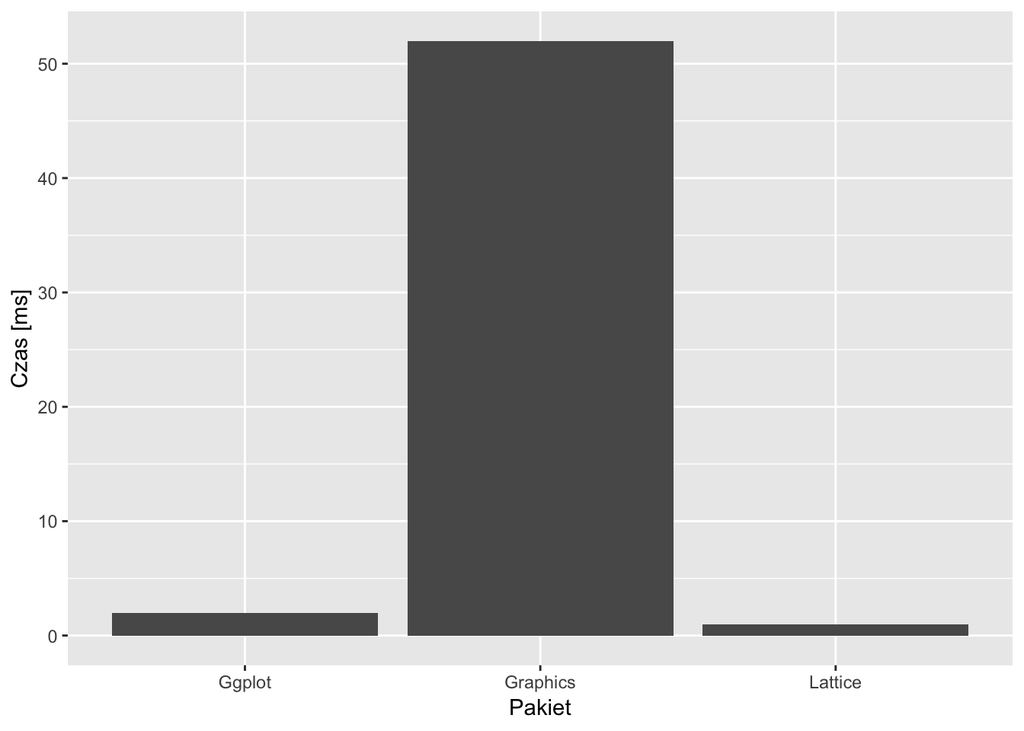

## 7.2 Histogram

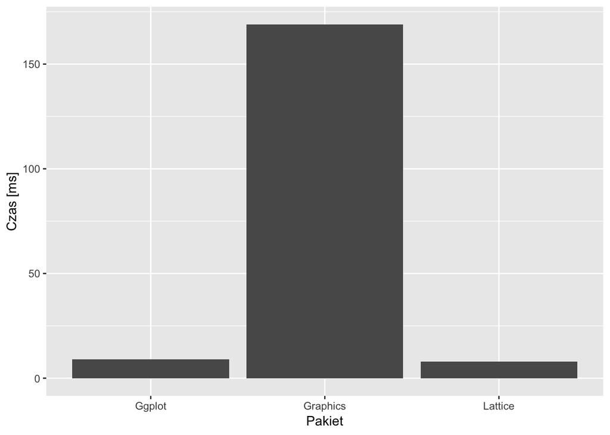

## 7.3 Bar plot

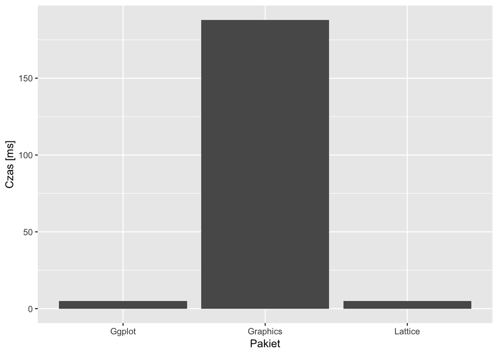

## 7.4 Line plot

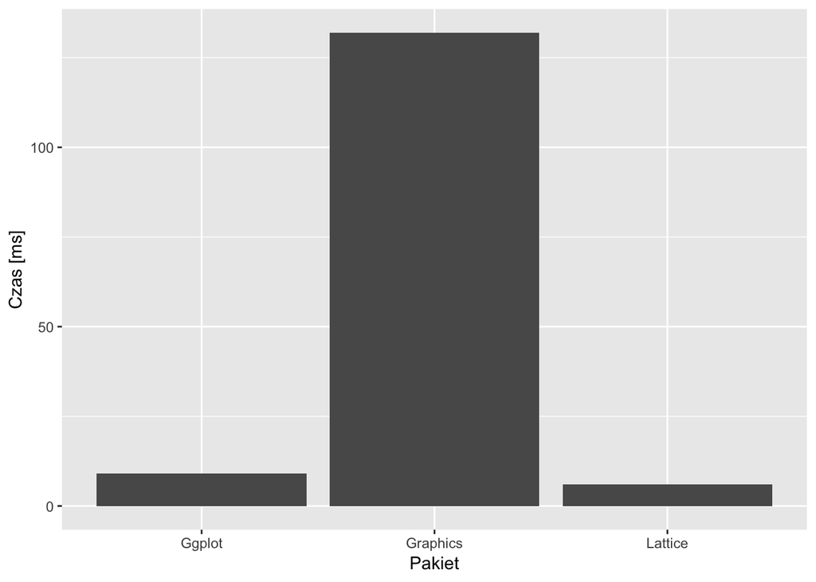

## 7.5 Boxplot

[figure not shown]